# Exporatory Analysis of Text Prediction

Jane

February 7, 2018

## Excutative Summary

This report is a exploratory analysis of swiftkey dataset. The dataset contains different locales and the data comes from blogs, twitter and news. The goal for us is to build a N -gram model using the training data and predict the next word based on the word sequence provided.

## Download and read the data

We have downloaded the dataset and extracted locally. We can see there are 4 locales, each locales contains 3 dataset, twitter, blogs, and news.

We can count the # of lines in each file by implementing a utility function getCountOfLines using the command “wc -l”. Here is the line count output.

```
##                         filename linecount wordcount
## 1    final/en_US/en_US.blogs.txt    899288 210160014
## 2     final/en_US/en_US.news.txt   1010242 205811885
## 3  final/en_US/en_US.twitter.txt   2360148 167105338
## 4    final/de_DE/de_DE.blogs.txt    371440  85459666
## 5     final/de_DE/de_DE.news.txt    244743  95591959
## 6  final/de_DE/de_DE.twitter.txt    947774  75578341
## 7    final/fi_FI/fi_FI.blogs.txt    439785 108503595
## 8     final/fi_FI/fi_FI.news.txt    485758  94234350
## 9  final/fi_FI/fi_FI.twitter.txt    285214  25331142
## 10   final/ru_RU/ru_RU.blogs.txt    337100 116855835
## 11    final/ru_RU/ru_RU.news.txt    196360 118996424
## 12 final/ru_RU/ru_RU.twitter.txt    881414 105182346
```

## Building Word frequency table using the n-gram model

Since we need to predict the word using n-gram, we will try build bi-gram, tri-gram, and qudra-gram. For bi-gram, the 1st word will be used to predict the next word (outcome). For the tri-gram, the first two words will be used to preduct the last word. For quadra gram, the first three words will be used to preduct the last word.

We tokenize our corpus first for each file, and build a sparse matrix of the n-gram tokens with the count of occurance, then we sum up all the count to build the frequency for each n-gram token.

Due to the size of the file is huge, we will use the sampling method to avoid using excessive memory, we can use k-folds to do multiple training later or to read the entire corpus. Since our training corpus containing different locale and different text source, we will make our model seperate for each source.

```r
 train.tokens <- tokens_wordstem(train.tokens,
                                    language = getStemLanguage(localeName))
 train.tokens <- tokens_ngrams(train.tokens, n = nGramModelUnit)
```

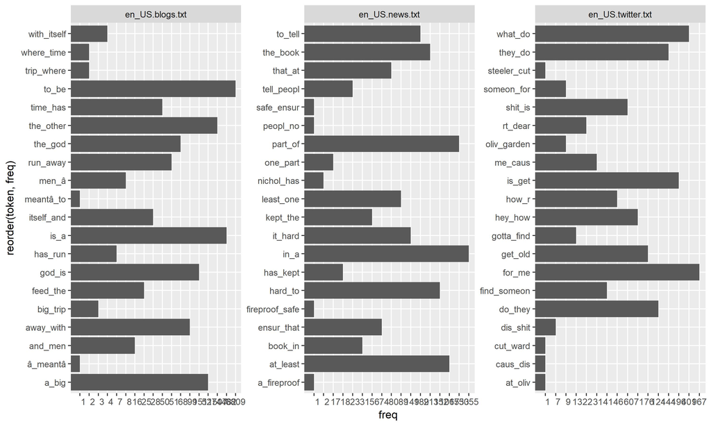

```r
include_graphics("./en_US_2gram_0.1.jpg")
```

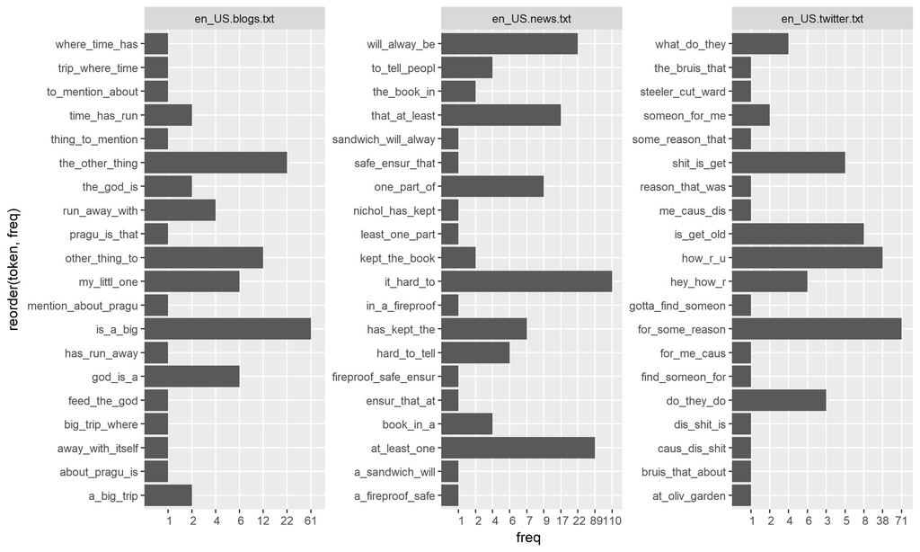

```r
include_graphics("./en_US_3gram_0.1.jpg")
```

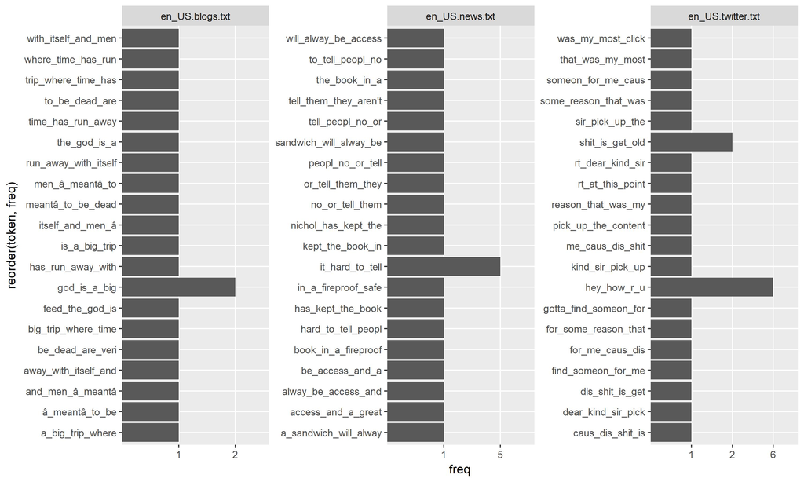

```r
include_graphics("./en_US_4gram_0.1.jpg")
```

## Statistics of the dataset

To check the performance and the statistics of the n-gram model we build, we listed the following stats in the table. From the table we can see the more sample size we build, the time spent are greater.

- The sample size (1 percent, 5 percent and 10 percent of the line count)
- Time spent in building the model
- Number of of n grams in the model
- Number of n grams that only appear once

```r
stat_list <- readRDS("stats_model_en_US.rds")
stat_list <- stat_list %>%
    mutate(filename=basename(as.character(filename))) %>%
    mutate(timespent=round(as.numeric(timespent)))
print(stat_list)
```

```
##             filename sample_size ngramUnits timespent  tokens
## 1    en_US.blogs.txt        0.01          4        57  300936
## 2     en_US.news.txt        0.01          4        70  304513
## 3  en_US.twitter.txt        0.01          4        53  206380
## 4    en_US.blogs.txt        0.05          4       405 1604484
## 5     en_US.news.txt        0.05          4       441 1464360
## 6  en_US.twitter.txt        0.05          4       448 1009221
## 7    en_US.blogs.txt         0.1          4       884 3168905
## 8     en_US.news.txt         0.1          4      1041 2895384
## 9  en_US.twitter.txt         0.1          4      1123 1963647
## 10   en_US.blogs.txt        0.01          2       338  157491
## 11    en_US.news.txt        0.01          2       340  174426
## 12 en_US.twitter.txt        0.01          2       324  129822
## 13   en_US.blogs.txt         0.1          2       593 1001615
## 14    en_US.news.txt         0.1          2       734 1017311
## 15 en_US.twitter.txt         0.1          2       855  787276
## 16   en_US.blogs.txt        0.01          3        65  274008
## 17    en_US.news.txt        0.01          3        81  285380
## 18 en_US.twitter.txt        0.01          3        96  203157
## 19   en_US.blogs.txt        0.05          3       410 1315494
## 20    en_US.news.txt        0.05          3       467 1254255
## 21 en_US.twitter.txt        0.05          3       491  905402
## 22   en_US.blogs.txt         0.1          3      1073 2465992
## 23    en_US.news.txt         0.1          3      1385 2358702
## 24 en_US.twitter.txt         0.1          3      1533 1681314
```

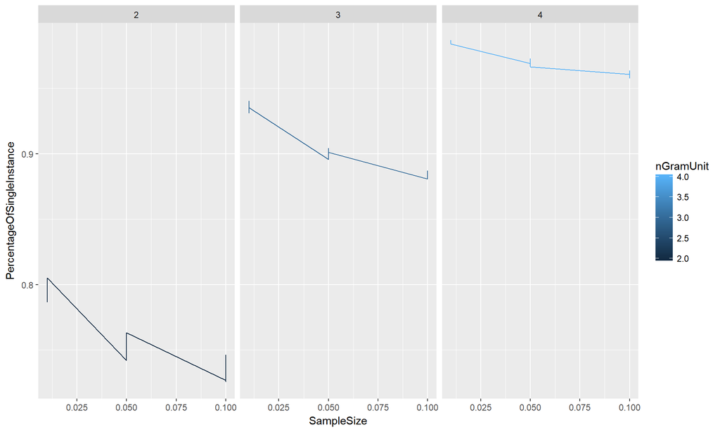

## Goal of building Shiny App for Prediction Model

In order to build a shiny app so that non-data scientest can also use, we have following requirements

- We need to allow user to choose on the shiny app which corpus source to build prediction from
- We need to allow user to input text (1 to 3 words), need to check if user’s language.
- After user input the above, we need to break down the input text to 1, 2, 3 word sequence and choose from the n-gram model and get the highest frequency from the n gram models.
- if the user input is not in the model (0 occurance), we will need to ask user to give us a hint and modify the model to include it, so it can learn from the user input on demand.

## Appendix

Source code for this rmd file can be find in github (https://github.com/jjtt8080/SwiftKey_Data_Capstone)